# Modelling regression trees with R’s caret package

[figure not shown]

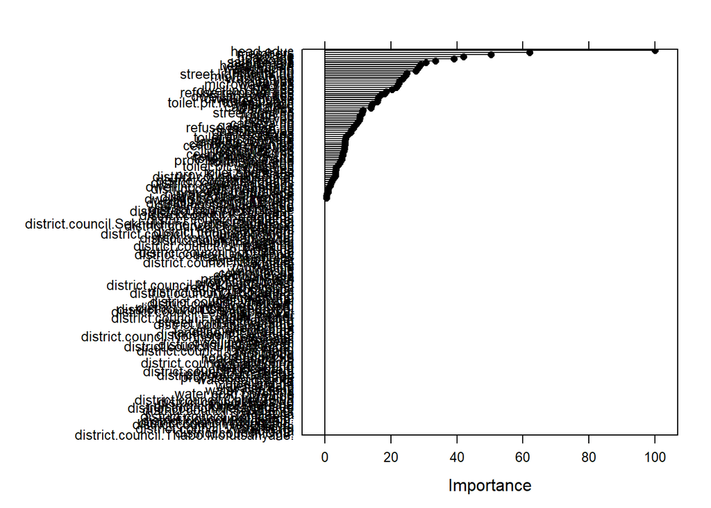

```
## rpart variable importance
##
##   only 20 most important variables shown (out of 188)
##
##                      Overall
## head.educ             100.00
## members                62.10
## roof.tile              50.24
## head.age               41.92
## rooms                  39.05
## satelite.yes           33.45
## head.male              30.59
## head.female            29.03
## water.piped            28.50
## washer.no              27.96
## satelite.no            27.46
## street.light.working   24.78
## microwave.no           24.50
## washer.yes             23.90
## hifi.no                23.58
## video.yes              22.50
## microwave.yes          22.34
## video.no               22.12
## hifi.yes               21.58
## dwelling.own.no        20.27
```

This is a very large model with 93 terminal nodes. Calling the final model shows model node numbers into the 2000s, but these numbers enumerate all of the potential splits at nodes below the max depth that were not enacted due to too small bins or too small an improvement in fit. The model has a depth of 12, which is too deep to sensibly plot or try to interepret.

Note that the same model can be obtained using any of the following commands:

```r
rpart(income ~ .,data=training,control=rpart.control(cp = 0.0008))

rpart(income ~ ., method="anova", data=training,control=rpart.control(minsplit = 20, minbucket = round(20/3), cp = 0.0008, maxcompete = 4, maxsurrogate = 5, usesurrogate = 2, xval = 10,surrogatestyle = 0, maxdepth = 30))

rpart(income ~ ., method="anova", data=training,control=rpart.control(cp = 0.0008))

train(income ~ ., training, method = "rpart", control = rpart.control(minsplit = 20, minbucket = round(20/3),maxcompete = 4, maxsurrogate = 5, usesurrogate = 2, xval = 10,surrogatestyle = 0, maxdepth = 30),tuneGrid=expand.grid(cp=0.0008))

train(income ~ ., training, method = "rpart", control = rpart.control(minsplit = 20, minbucket = round(20/3),maxdepth = 30),tuneGrid=expand.grid(cp=0.0008))
```

The one standard error rule suggests that we should choose the simplest model which performs no more than one standard error worse than the best fit. In Monte-Carlo trials, this method of tuning has proven very reliable for screening out “pure noise” variables in data sets.

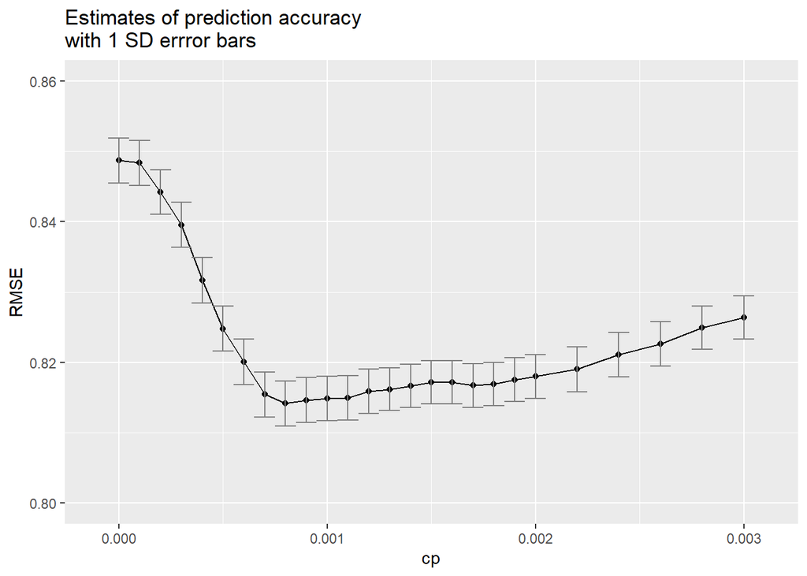

```r
Grid <- expand.grid(cp=c(seq(0, 0.002, 0.0001),seq(0.002, 0.003, 0.0002)))
train(formula, data=training, method = 'rpart', trControl=fitControl,tuneGrid=Grid)
```

The graph suggests that a cp value of around 0.0024 would produce a RMSE that is only 1 SD worse than the optimal RMSE. We can estimate what this model looks like:

```r
part.fit.1SD <- train(formula, data=training, method = 'rpart', trControl=fitControl,tuneGrid=expand.grid(cp=0.0024))
```

```r
rpart.fit.1SD.rmse
rpart.fit.1SD.tab
```

```
## rpart variable importance
##
##   only 20 most important variables shown (out of 188)
##
##                          Overall
## head.educ                 100.00
## washer.no                  85.92
## members                    76.69
## washer.yes                 73.11
## microwave.no               59.42
## microwave.yes              41.51
## water.piped                39.78
## rooms                      33.11
## toilet.pit.noventilation   32.46
## hifi.no                    31.18
## refuse.removal.yes         25.85
## roof.tile                  23.79
## video.yes                  20.94
## satelite.no                19.81
## hifi.yes                   19.37
## computer.yes               18.84
## computer.no                18.64
## fridge.no                  17.66
## street.light.working       17.51
## landline.working           16.90
```

```
## n= 4682
##
## node), split, n, deviance, yval
##       * denotes terminal node
##
##   1) root 4682 6550.380000 6.704452
##     2) computer.yes< 0.5 4101 4518.763000 6.495475
##       4) members>=2.5 2675 2095.186000 6.169479
##         8) microwave.no>=0.5 1852 1126.014000 5.944017
##          16) water.piped< 0.5 1411  795.840500 5.834787
##            32) members>=5.5 531  250.169300 5.643026 *
##            33) members< 5.5 880  514.363100 5.950497
##              66) hifi.no>=0.5 664  357.863900 5.868057 *
##              67) hifi.no< 0.5 216  138.113700 6.203924 *
##          17) water.piped>=0.5 441  259.473400 6.293506
##            34) members>=3.5 335  179.458400 6.177559 *
##            35) members< 3.5 106   61.278040 6.659942 *
##         9) microwave.no< 0.5 823  663.179400 6.676837
##          18) washer.yes< 0.5 413  272.280000 6.373718
##            36) hifi.no>=0.5 169   94.221250 6.104736 *
##            37) hifi.no< 0.5 244  157.362300 6.560022 *
##          19) washer.yes>=0.5 410  314.728300 6.982173
##            38) members>=4.5 192  113.535100 6.683199 *
##            39) members< 4.5 218  168.916100 7.245490
##              78) head.educ< 11.5 115   77.588010 6.958545 *
##              79) head.educ>=11.5 103   71.287300 7.565865 *
##       5) members< 2.5 1426 1606.020000 7.107003
##        10) washer.no>=0.5 1208 1131.587000 6.929046
##          20) members>=1.5 526  357.848200 6.535038
##            40) fridge.no>=0.5 330  212.315800 6.349281 *
##            41) fridge.no< 0.5 196  114.973800 6.847792 *
##          21) members< 1.5 682  629.101900 7.232930
##            42) cellphone.own.yes< 0.5 250  199.287200 6.817923 *
##            43) cellphone.own.yes>=0.5 432  361.839500 7.473096
##              86) dwelling.shack>=0.5 46   29.534450 6.814853 *
##              87) dwelling.shack< 0.5 386  309.998800 7.551539
##               174) street.light.working< 0.5 206  147.699800 7.355517 *
##               175) street.light.working>=0.5 180  145.324600 7.775876 *
##        11) washer.no< 0.5 218  224.192900 8.093110
##          22) head.educ< 6.5 25    6.143150 7.059301 *
##          23) head.educ>=6.5 193  187.869700 8.227023
##            46) satelite.no>=0.5 137  122.104300 8.023682 *
##            47) satelite.no< 0.5 56   46.242730 8.724482 *
##     3) computer.yes>=0.5 581  588.366100 8.179520
##       6) head.educ< 11.5 135  109.440300 7.445603 *
##       7) head.educ>=11.5 446  384.199900 8.401670
##        14) members>=3.5 195  159.425100 8.033211
##          28) head.educ>=24.5 10    2.139386 6.263327 *
##          29) head.educ< 24.5 185  124.267600 8.128880
##            58) rooms< 6.5 113   70.523820 7.888100 *
##            59) rooms>=6.5 72   36.910990 8.506770 *
##        15) members< 3.5 251  177.734000 8.687923
##          30) landline.working< 0.5 104   71.641570 8.363451 *
##          31) landline.working>=0.5 147   87.396700 8.917481 *
```

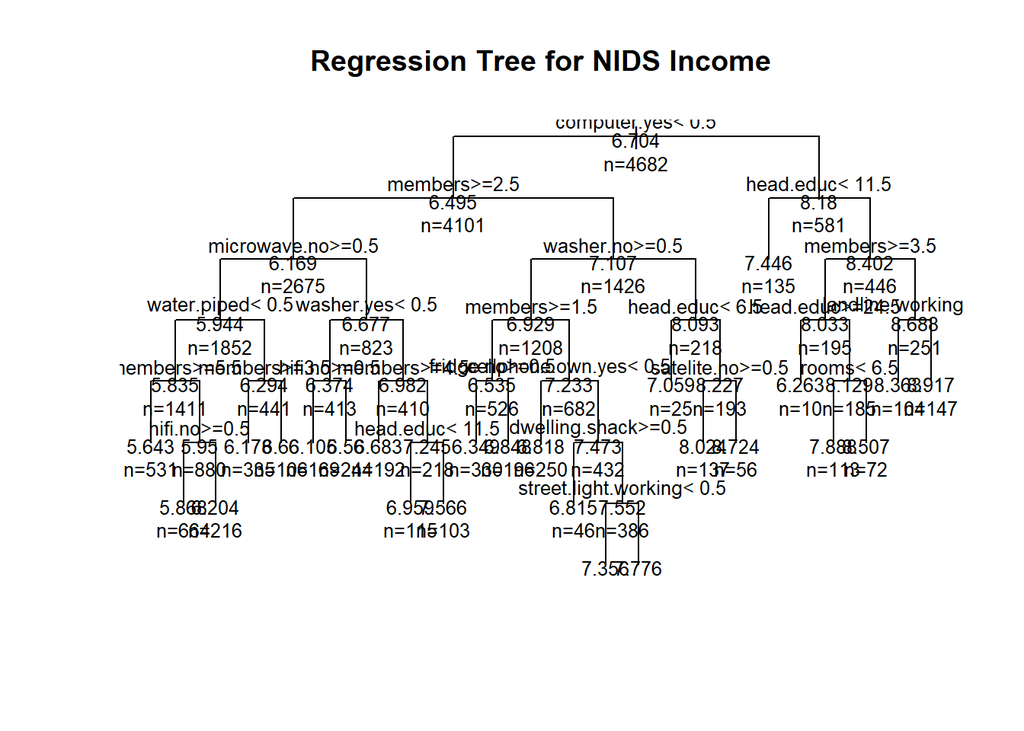

Choosing a cp value that is 1SD higher than the optimal value produces a considerably simpler tree, although it is perhaps still too complicated to interpret in terms of the decision rules. It has a depth of 8 and only 25 terminal nodes.

`caret` also offers an automated way to select the cp value that is 1SD larger than RMSE minimising value: method `rpart1SE`

```r
train(formula, data=training, method = 'rpart1SE', trControl=fitControl, tuneLength = 10)
```

```r
rpart.fit.1SD.rmse
rpart.fit.1SD.tab
```

```r
rpart1SE.fit1=rpart(income ~ ., method="anova", data=training,control=rpart.control(cp = 0.0008))
plotcp(rpart1SE.fit1)
rpart1SE.fit1=rpart(income ~ ., method="anova", data=training,control=rpart.control(cp = 0.004))
```

Cp is the only value that caret allow the rpart function to tune. However, rpart2 can be used to tune the maxdepth

```r
set.seed(123)
train(formula, data=training, method = 'rpart2', trControl=fitControl, tuneLength = 10)
```

```r
Grid <- expand.grid(maxdepth=seq(15, 30, 2))
train(formula, data=training, method = 'rpart2', trControl=fitControl,tuneGrid=Grid, control=rpart.control(cp = 0.0001,minsplit = 20))
```

```
## CART
##
## 4682 samples
##  188 predictor
##
## No pre-processing
## Resampling: Cross-Validated (10 fold, repeated 10 times)
## Summary of sample sizes: 4214, 4214, 4214, 4214, 4214, 4214, ...
## Resampling results across tuning parameters:
##
##   maxdepth  RMSE       Rsquared
##   15        0.8281214  0.5111269
##   17        0.8271299  0.5124570
##   19        0.8257746  0.5141327
##   21        0.8241489  0.5161755
##   23        0.8217987  0.5190499
##   25        0.8209227  0.5202624
##   27        0.8195764  0.5219224
##   29        0.8483490  0.5082782
##
## RMSE was used to select the optimal model using the smallest value.
## The final value used for the model was maxdepth = 27.
```